# Project: Data Wrangling "WeRateDogs"

## Data Gathering

```python
#Import statements for all of the packages will be used
import pandas as pd
import numpy as np
%matplotlib inline
import matplotlib.pyplot as plt
import seaborn as sns
import requests
import os
import tweepy
import json
```

```python
# read Twitter archive file and store it as dataframe(twitter_archive)
twitter_archive_df = pd.read_csv('twitter-archive-enhanced.csv')
twitter_archive_df.head(2)
```

|  | tweet_id | in_reply_to_status_id | in_reply_to_user_id | timestamp | source | text | retweeted_status_id | retweeted_status_user_id | retweeted_status_timestamp | expanded_urls | rating_numerator | rating_denominator | name | doggo | floofer | pupper | puppo |
| --- | --- | --- | --- | --- | --- | --- | --- | --- | --- | --- | --- | --- | --- | --- | --- | --- | --- |
| 0 | 892420643555336193 | NaN | NaN | 2017-08-01 16:23:56 +0000 | <a href="http://twitter.com/download/iphone" r... | This is Phineas. He's a mystical boy. Only eve... | NaN | NaN | NaN | https://twitter.com/dog_rates/status/892420643... | 13 | 10 | Phineas | None | None | None | None |
| 1 | 892177421306343426 | NaN | NaN | 2017-08-01 00:17:27 +0000 | <a href="http://twitter.com/download/iphone" r... | This is Tilly. She's just checking pup on you.... | NaN | NaN | NaN | https://twitter.com/dog_rates/status/892177421... | 13 | 10 | Tilly | None | None | None | None |

```python
twitter_archive_df.info()
```

```
<class 'pandas.core.frame.DataFrame'>
RangeIndex: 2356 entries, 0 to 2355
Data columns (total 17 columns):
tweet_id                      2356 non-null int64
in_reply_to_status_id         78 non-null float64
in_reply_to_user_id           78 non-null float64
timestamp                     2356 non-null object
source                        2356 non-null object
text                          2356 non-null object
retweeted_status_id           181 non-null float64
retweeted_status_user_id      181 non-null float64
retweeted_status_timestamp    181 non-null object
expanded_urls                 2297 non-null object
rating_numerator              2356 non-null int64
rating_denominator            2356 non-null int64
name                          2356 non-null object
doggo                         2356 non-null object
floofer                       2356 non-null object
pupper                        2356 non-null object
puppo                         2356 non-null object
dtypes: float64(4), int64(3), object(10)
memory usage: 313.0+ KB
```

```python
# download image predictions file programmatically by using request library
url = 'https://d17h27t6h515a5.cloudfront.net/topher/2017/August/599fd2ad_image-predictions/image-predictions.tsv'
response = requests.get(url)
with open(url.split('/')[-1], mode = 'wb') as file:
    file.write(response.content)
```

```python
# read image predictions file and store it as image
image = pd.read_csv('image-predictions.tsv' , sep='\t')
image.sample(2)
```

|  | tweet_id | jpg_url | img_num | p1 | p1_conf | p1_dog | p2 | p2_conf | p2_dog | p3 | p3_conf | p3_dog |
| --- | --- | --- | --- | --- | --- | --- | --- | --- | --- | --- | --- | --- |
| 1382 | 765395769549590528 | https://pbs.twimg.com/media/Cp87Y0jXYAQyjuV.jpg | 1 | Pembroke | 0.509491 | True | Cardigan | 0.330401 | True | Shetland_sheepdog | 0.038875 | True |
| 1389 | 766423258543644672 | https://pbs.twimg.com/media/CqLh4yJWcAAHomv.jpg | 2 | keeshond | 0.995823 | True | Pomeranian | 0.003897 | True | Norwegian_elkhound | 0.000253 | True |

```python
# Query the Twitter API by using tweepy library
# API kyes are hidden since it is standard practice for APIs and public code
consumer_key = 'HIDDEN'
consumer_secret = 'HIDDEN'
access_token = 'HIDDEN'
access_token_secret = 'HIDDEN'

auth = tweepy.OAuthHandler(consumer_key, consumer_secret)
auth.set_access_token(access_token, access_token_secret)

api = tweepy.API(auth, parser=tweepy.parsers.JSONParser())
```

```python
# Collect data after calling Twitter API
tweet_ids = list(twitter_archive_df['tweet_id'])

tweet_data = []
tweet_id_success = []
tweet_id_missing = []
for tweet_id in tweet_ids:
    try:
        data = api.get_status(tweet_id,
                              tweet_mode='extended',
                              wait_on_rate_limit = True,
                              wait_on_rate_limit_notify = True)
        tweet_data.append(data)
        tweet_id_success.append(tweet_id)
    except:
        tweet_id_missing.append(tweet_id)
        print(tweet_id)
```

```
888202515573088257
873697596434513921
872668790621863937
872261713294495745
869988702071779329
866816280283807744
861769973181624320
856602993587888130
851953902622658560
845459076796616705
844704788403113984
842892208864923648
837366284874571778
837012587749474308
829374341691346946
827228250799742977
812747805718642688
802247111496568832
779123168116150273
775096608509886464
771004394259247104
770743923962707968
759566828574212096
Rate limit reached. Sleeping for: 734
754011816964026368
680055455951884288
Rate limit reached. Sleeping for: 735
```

```python
# write JSON data in tweet_json.txt
with open('tweet_json.txt', mode = 'w') as file:
    json.dump(tweet_data, file)
```

```python
# Load the Twitter API info
tweet_api = pd.read_json('tweet_json.txt')
tweet_api['tweet_id'] = tweet_id_success
tweet_api = tweet_api[['tweet_id', 'favorite_count', 'retweet_count']]

tweet_api.head(2)
```

|  | tweet_id | favorite_count | retweet_count |
| --- | --- | --- | --- |
| 0 | 892420643555336193 | 36232 | 7712 |
| 1 | 892177421306343426 | 31256 | 5699 |

## Data Assessment

```python
# View info of twitter archive df
twitter_archive_df.info()
```

```
<class 'pandas.core.frame.DataFrame'>
RangeIndex: 2356 entries, 0 to 2355
Data columns (total 17 columns):
tweet_id                      2356 non-null int64
in_reply_to_status_id         78 non-null float64
in_reply_to_user_id           78 non-null float64
timestamp                     2356 non-null object
source                        2356 non-null object
text                          2356 non-null object
retweeted_status_id           181 non-null float64
retweeted_status_user_id      181 non-null float64
retweeted_status_timestamp    181 non-null object
expanded_urls                 2297 non-null object
rating_numerator              2356 non-null int64
rating_denominator            2356 non-null int64
name                          2356 non-null object
doggo                         2356 non-null object
floofer                       2356 non-null object
pupper                        2356 non-null object
puppo                         2356 non-null object
dtypes: float64(4), int64(3), object(10)
memory usage: 313.0+ KB
```

```python
## View descriptive statistics of twitter archive df
twitter_archive_df.describe()
```

|  | tweet_id | in_reply_to_status_id | in_reply_to_user_id | retweeted_status_id | retweeted_status_user_id | rating_numerator | rating_denominator |
| --- | --- | --- | --- | --- | --- | --- | --- |
| count | 2.356000e+03 | 7.800000e+01 | 7.800000e+01 | 1.810000e+02 | 1.810000e+02 | 2356.000000 | 2356.000000 |
| mean | 7.427716e+17 | 7.455079e+17 | 2.014171e+16 | 7.720400e+17 | 1.241698e+16 | 13.126486 | 10.455433 |
| std | 6.856705e+16 | 7.582492e+16 | 1.252797e+17 | 6.236928e+16 | 9.599254e+16 | 45.876648 | 6.745237 |
| min | 6.660209e+17 | 6.658147e+17 | 1.185634e+07 | 6.661041e+17 | 7.832140e+05 | 0.000000 | 0.000000 |
| 25% | 6.783989e+17 | 6.757419e+17 | 3.086374e+08 | 7.186315e+17 | 4.196984e+09 | 10.000000 | 10.000000 |
| 50% | 7.196279e+17 | 7.038708e+17 | 4.196984e+09 | 7.804657e+17 | 4.196984e+09 | 11.000000 | 10.000000 |
| 75% | 7.993373e+17 | 8.257804e+17 | 4.196984e+09 | 8.203146e+17 | 4.196984e+09 | 12.000000 | 10.000000 |
| max | 8.924206e+17 | 8.862664e+17 | 8.405479e+17 | 8.874740e+17 | 7.874618e+17 | 1776.000000 | 170.000000 |

```python
# View first 2 rows of of twitter archive df
twitter_archive_df.head(2)
```

|  | tweet_id | in_reply_to_status_id | in_reply_to_user_id | timestamp | source | text | retweeted_status_id | retweeted_status_user_id | retweeted_status_timestamp | expanded_urls | rating_numerator | rating_denominator | name | doggo | floofer | pupper | puppo |
| --- | --- | --- | --- | --- | --- | --- | --- | --- | --- | --- | --- | --- | --- | --- | --- | --- | --- |
| 0 | 892420643555336193 | NaN | NaN | 2017-08-01 16:23:56 +0000 | <a href="http://twitter.com/download/iphone" r... | This is Phineas. He's a mystical boy. Only eve... | NaN | NaN | NaN | https://twitter.com/dog_rates/status/892420643... | 13 | 10 | Phineas | None | None | None | None |
| 1 | 892177421306343426 | NaN | NaN | 2017-08-01 00:17:27 +0000 | <a href="http://twitter.com/download/iphone" r... | This is Tilly. She's just checking pup on you.... | NaN | NaN | NaN | https://twitter.com/dog_rates/status/892177421... | 13 | 10 | Tilly | None | None | None | None |

```python
# check names consistency
twitter_archive_df.name.str.islower().sum()
```

```
109
```

```python
# find the total missing values for each features of twitter archive df
twitter_archive_df.isnull().sum()
```

```
tweet_id                         0
in_reply_to_status_id         2278
in_reply_to_user_id           2278
timestamp                        0
source                           0
text                             0
retweeted_status_id           2175
retweeted_status_user_id      2175
retweeted_status_timestamp    2175
expanded_urls                   59
rating_numerator                 0
rating_denominator               0
name                             0
doggo                            0
floofer                          0
pupper                           0
puppo                            0
dtype: int64
```

```python
# check if there is a denominator other than 10
twitter_archive_df.rating_denominator.value_counts()
```

```
10     2333
11        3
50        3
80        2
20        2
2         1
16        1
40        1
70        1
15        1
90        1
110       1
120       1
130       1
150       1
170       1
7         1
0         1
Name: rating_denominator, dtype: int64
```

```python
# View last 2 rows of image predictions df
image.tail(2)
```

|  | tweet_id | jpg_url | img_num | p1 | p1_conf | p1_dog | p2 | p2_conf | p2_dog | p3 | p3_conf | p3_dog |
| --- | --- | --- | --- | --- | --- | --- | --- | --- | --- | --- | --- | --- |
| 2073 | 892177421306343426 | https://pbs.twimg.com/media/DGGmoV4XsAAUL6n.jpg | 1 | Chihuahua | 0.323581 | True | Pekinese | 0.090647 | True | papillon | 0.068957 | True |
| 2074 | 892420643555336193 | https://pbs.twimg.com/media/DGKD1-bXoAAIAUK.jpg | 1 | orange | 0.097049 | False | bagel | 0.085851 | False | banana | 0.076110 | False |

```python
# View info of image predictions df
image.info()
```

```
<class 'pandas.core.frame.DataFrame'>
RangeIndex: 2075 entries, 0 to 2074
Data columns (total 12 columns):
tweet_id    2075 non-null int64
jpg_url     2075 non-null object
img_num     2075 non-null int64
p1          2075 non-null object
p1_conf     2075 non-null float64
p1_dog      2075 non-null bool
p2          2075 non-null object
p2_conf     2075 non-null float64
p2_dog      2075 non-null bool
p3          2075 non-null object
p3_conf     2075 non-null float64
p3_dog      2075 non-null bool
dtypes: bool(3), float64(3), int64(2), object(4)
memory usage: 152.1+ KB
```

```python
# View descriptive statistics of image predictions df
image.describe()
```

|  | tweet_id | img_num | p1_conf | p2_conf | p3_conf |
| --- | --- | --- | --- | --- | --- |
| count | 2.075000e+03 | 2075.000000 | 2075.000000 | 2.075000e+03 | 2.075000e+03 |
| mean | 7.384514e+17 | 1.203855 | 0.594548 | 1.345886e-01 | 6.032417e-02 |
| std | 6.785203e+16 | 0.561875 | 0.271174 | 1.006657e-01 | 5.090593e-02 |
| min | 6.660209e+17 | 1.000000 | 0.044333 | 1.011300e-08 | 1.740170e-10 |
| 25% | 6.764835e+17 | 1.000000 | 0.364412 | 5.388625e-02 | 1.622240e-02 |
| 50% | 7.119988e+17 | 1.000000 | 0.588230 | 1.181810e-01 | 4.944380e-02 |
| 75% | 7.932034e+17 | 1.000000 | 0.843855 | 1.955655e-01 | 9.180755e-02 |
| max | 8.924206e+17 | 4.000000 | 1.000000 | 4.880140e-01 | 2.734190e-01 |

```python
# find the duplicated values of image predictions df
image.duplicated().sum()
```

```
0
```

```python
# find the total missing values for each features of image predictions df
image.isnull().sum()
```

```
tweet_id    0
jpg_url     0
img_num     0
p1          0
p1_conf     0
p1_dog      0
p2          0
p2_conf     0
p2_dog      0
p3          0
p3_conf     0
p3_dog      0
dtype: int64
```

```python
# View the first 2 rows of tweet info df
tweet_api.head(2)
```

|  | tweet_id | favorite_count | retweet_count |
| --- | --- | --- | --- |
| 0 | 892420643555336193 | 36232 | 7712 |
| 1 | 892177421306343426 | 31256 | 5699 |

```python
## View descriptive statistics of tweet info df
tweet_api.describe()
```

|  | tweet_id | favorite_count | retweet_count |
| --- | --- | --- | --- |
| count | 2.331000e+03 | 2331.000000 | 2331.000000 |
| mean | 7.419079e+17 | 7567.214071 | 2705.717718 |
| std | 6.823170e+16 | 11745.984530 | 4575.340857 |
| min | 6.660209e+17 | 0.000000 | 1.000000 |
| 25% | 6.782670e+17 | 1319.500000 | 548.000000 |
| 50% | 7.182469e+17 | 3289.000000 | 1268.000000 |
| 75% | 7.986692e+17 | 9264.500000 | 3143.500000 |
| max | 8.924206e+17 | 156326.000000 | 77860.000000 |

```python
# View info of tweet info df
tweet_api.info()
```

```
<class 'pandas.core.frame.DataFrame'>
RangeIndex: 2331 entries, 0 to 2330
Data columns (total 3 columns):
tweet_id          2331 non-null int64
favorite_count    2331 non-null int64
retweet_count     2331 non-null int64
dtypes: int64(3)
memory usage: 54.7 KB
```

```python
tweet_api.duplicated().sum()
```

```
0
```

### Quality Issues

#### twitter_archive_df

- The timestamp column is in string format.
- Columns( "in_reply_to_status_id", "in_reply_to_user_id", "retweeted_status_id", "in_reply_to_user_id", "retweeted_status_id", "retweeted_status_user_id", "retweeted_status_timestamp) have many missing values. reply and retweeted columns will not be used.
- "expanded_urls" varaible has missing values, which means some tweets have no images.
- Some dogs names are capitalize and other not.
- Incorrect some dog names.
- Some values of ‘rating_denominator’ != 10.
- Some values of 'rating_numerator' are incorrect.
- Missing values in 'name' = 'None'

### Tidiness Issues

- There are 4 columns for dog "stage" (doggo, floffer, pupper, and puppo) in the "twitter_archive_df"
- We have 3 different datasets 'tweet_info','image', and 'twitter_archive_df'

## Data Cleaning

```python
# make copies of dataframes for cleaning
twitter_archive_clean = twitter_archive_df.copy()
image_clean = image.copy()
tweet_api_clean = tweet_api.copy()
```

### 1) Tidiness Issue:

#### Define

Will create one column for dog stages that has (doggo, floffer, pupper, and puppo)and call it dog_stage

##### Code

```python
twitter_archive_clean['dog_stage'] = twitter_archive_clean['text'].str.extract('(puppo|pupper|floofer|doggo)', expand=True)
```

```python
# drop the doggo, floffer, pupper, and puppo columns
columns = ['doggo', 'floofer', 'pupper', 'puppo']
twitter_archive_clean = twitter_archive_clean.drop(columns, axis=1)
```

#### Test

```python
twitter_archive_clean.sample(3)
```

|  | tweet_id | in_reply_to_status_id | in_reply_to_user_id | timestamp | source | text | retweeted_status_id | retweeted_status_user_id | retweeted_status_timestamp | expanded_urls | rating_numerator | rating_denominator | name | dog_stage |
| --- | --- | --- | --- | --- | --- | --- | --- | --- | --- | --- | --- | --- | --- | --- |
| 1289 | 708149363256774660 | NaN | NaN | 2016-03-11 04:35:39 +0000 | <a href="http://twitter.com/download/iphone" r... | This is Jebberson. He's the reigning hide and ... | NaN | NaN | NaN | https://twitter.com/dog_rates/status/708149363... | 10 | 10 | Jebberson | NaN |
| 276 | 840632337062862849 | NaN | NaN | 2017-03-11 18:35:42 +0000 | <a href="http://twitter.com/download/iphone" r... | Say hello to Maddie and Gunner. They are consi... | NaN | NaN | NaN | https://www.gofundme.com/3hgsuu0,https://twitt... | 12 | 10 | Maddie | NaN |
| 1305 | 707387676719185920 | NaN | NaN | 2016-03-09 02:08:59 +0000 | <a href="http://twitter.com/download/iphone" r... | Meet Clarkus. He's a Skinny Eastern Worcesters... | NaN | NaN | NaN | https://twitter.com/dog_rates/status/707387676... | 10 | 10 | Clarkus | NaN |

### 2) Tidiness Issue:

#### Define

Merge 'tweet_ifno_clean','image_clean' into one datafram ( twitter_archive_clean)

##### Code

```python
# Merge image_clean to twitter_archive_clean
twitter_archive_clean = pd.merge(twitter_archive_clean, image_clean,on='tweet_id', how='inner')
```

```python
# tweet_api_clean to twitter_archive_clean
twitter_archive_clean = twitter_archive_clean.merge(tweet_api_clean, on='tweet_id', how='inner')
```

```python
twitter_archive_clean.duplicated().sum()
```

```
0
```

#### Test

```python
twitter_archive_clean.info()
```

```
<class 'pandas.core.frame.DataFrame'>
Int64Index: 2059 entries, 0 to 2058
Data columns (total 27 columns):
tweet_id                      2059 non-null int64
in_reply_to_status_id         23 non-null float64
in_reply_to_user_id           23 non-null float64
timestamp                     2059 non-null object
source                        2059 non-null object
text                          2059 non-null object
retweeted_status_id           72 non-null float64
retweeted_status_user_id      72 non-null float64
retweeted_status_timestamp    72 non-null object
expanded_urls                 2059 non-null object
rating_numerator              2059 non-null int64
rating_denominator            2059 non-null int64
name                          2059 non-null object
dog_stage                     334 non-null object
jpg_url                       2059 non-null object
img_num                       2059 non-null int64
p1                            2059 non-null object
p1_conf                       2059 non-null float64
p1_dog                        2059 non-null bool
p2                            2059 non-null object
p2_conf                       2059 non-null float64
p2_dog                        2059 non-null bool
p3                            2059 non-null object
p3_conf                       2059 non-null float64
p3_dog                        2059 non-null bool
favorite_count                2059 non-null int64
retweet_count                 2059 non-null int64
dtypes: bool(3), float64(7), int64(6), object(11)
memory usage: 408.2+ KB
```

### 1) Quality Issue:

#### Define

Drop tweets with missing values in the expanded_urls

#### Code

```python
twitter_archive_clean = twitter_archive_clean[twitter_archive_clean.expanded_urls.notnull()]
```

#### Test

```python
sum(twitter_archive_clean['expanded_urls'].isnull())
```

```
0
```

### 2) Quality Issue:

#### Define

Remove unnecessary columns (n_reply_to_status_id", "in_reply_to_user_id", "retweeted_status_id", "in_reply_to_user_id", "retweeted_status_id", "retweeted_status_user_id", "retweeted_status_timestamp)

#### Code

```python
columns = ['retweeted_status_id', 'retweeted_status_user_id', 'retweeted_status_timestamp', 'in_reply_to_status_id', 'in_reply_to_user_id','in_reply_to_user_id']
twitter_archive_clean = twitter_archive_clean.drop(columns, axis = 1)
```

#### Test

```python
list(twitter_archive_clean)
```

```
['tweet_id',
 'timestamp',
 'source',
 'text',
 'expanded_urls',
 'rating_numerator',
 'rating_denominator',
 'name',
 'dog_stage',
 'jpg_url',
 'img_num',
 'p1',
 'p1_conf',
 'p1_dog',
 'p2',
 'p2_conf',
 'p2_dog',
 'p3',
 'p3_conf',
 'p3_dog',
 'favorite_count',
 'retweet_count']
```

### 3) Quality Issue:

#### Define

change incorrect dog names (an, a, the) to None

#### Code

```python
twitter_archive_clean['name'].value_counts().head()
```

```
None      573
a          55
Cooper     10
Oliver     10
Tucker     10
Name: name, dtype: int64
```

```python
incorrect_names = ['a','the','an']
for i in incorrect_names:
        twitter_archive_clean['name'].replace(i, 'None', inplace=True)
```

#### Test

```python
twitter_archive_clean['name'].value_counts().head()
```

```
None      642
Cooper     10
Oliver     10
Penny      10
Tucker     10
Name: name, dtype: int64
```

### 4) Quality Issue:

#### Define

Drop all values of ‘rating_denominator’ != 10

#### Code

```python
twitter_archive_clean.rating_denominator.value_counts()
```

```
10     2041
50        3
11        2
80        2
7         1
170       1
150       1
130       1
120       1
110       1
90        1
70        1
40        1
20        1
2         1
Name: rating_denominator, dtype: int64
```

```python
twitter_archive_clean = twitter_archive_clean[twitter_archive_clean.rating_denominator == 10]
```

#### Test

```python
twitter_archive_clean.rating_denominator.value_counts()
```

```
10    2041
Name: rating_denominator, dtype: int64
```

### 5) Quality Issue:

#### Define

Drop all values of rating_numerator > 20

#### Code

```python
twitter_archive_clean.rating_numerator.value_counts()
```

```
12      471
10      427
11      413
13      275
9       150
8        95
7        51
14       38
5        34
6        32
3        19
4        15
2         9
1         4
0         2
420       1
15        1
26        1
27        1
75        1
1776      1
Name: rating_numerator, dtype: int64
```

```python
twitter_archive_clean = twitter_archive_clean[twitter_archive_clean.rating_numerator < 20]
```

#### Test

```python
twitter_archive_clean.rating_numerator.value_counts()
```

```
12    471
10    427
11    413
13    275
9     150
8      95
7      51
14     38
5      34
6      32
3      19
4      15
2       9
1       4
0       2
15      1
Name: rating_numerator, dtype: int64
```

### 6) Quality Issue:

#### Define

Change timestamp column from string to datetime format

#### Code

```python
twitter_archive_clean.timestamp = pd.to_datetime(twitter_archive_clean.timestamp)
```

#### Test

```python
twitter_archive_clean.info()
```

```
<class 'pandas.core.frame.DataFrame'>
Int64Index: 2036 entries, 0 to 2058
Data columns (total 22 columns):
tweet_id              2036 non-null int64
timestamp             2036 non-null datetime64[ns]
source                2036 non-null object
text                  2036 non-null object
expanded_urls         2036 non-null object
rating_numerator      2036 non-null int64
rating_denominator    2036 non-null int64
name                  2036 non-null object
dog_stage             326 non-null object
jpg_url               2036 non-null object
img_num               2036 non-null int64
p1                    2036 non-null object
p1_conf               2036 non-null float64
p1_dog                2036 non-null bool
p2                    2036 non-null object
p2_conf               2036 non-null float64
p2_dog                2036 non-null bool
p3                    2036 non-null object
p3_conf               2036 non-null float64
p3_dog                2036 non-null bool
favorite_count        2036 non-null int64
retweet_count         2036 non-null int64
dtypes: bool(3), datetime64[ns](1), float64(3), int64(6), object(9)
memory usage: 324.1+ KB
```

### 7) Quality Issue:

#### Define

Capitalize dog names

#### Code

```python
twitter_archive_clean['name'].str.islower().sum()
```

```
30
```

```python
twitter_archive_clean['name'] = twitter_archive_clean.name.str.capitalize()
```

#### Test

```python
twitter_archive_clean['name'].str.islower().sum()
```

```
0
```

### 8) Quality Issue:

#### Define

change missing values in 'name' from 'None' to 'NaN'

#### Code

```python
twitter_archive_clean.tail(1)
```

|  | tweet_id | timestamp | source | text | expanded_urls | rating_numerator | rating_denominator | name | dog_stage | jpg_url | ... | p1_conf | p1_dog | p2 | p2_conf | p2_dog | p3 | p3_conf | p3_dog | favorite_count | retweet_count |
| --- | --- | --- | --- | --- | --- | --- | --- | --- | --- | --- | --- | --- | --- | --- | --- | --- | --- | --- | --- | --- | --- |
| 2058 | 666020888022790149 | 2015-11-15 22:32:08 | <a href="http://twitter.com/download/iphone" r... | Here we have a Japanese Irish Setter. Lost eye... | https://twitter.com/dog_rates/status/666020888... | 8 | 10 | None | NaN | https://pbs.twimg.com/media/CT4udn0WwAA0aMy.jpg | ... | 0.465074 | True | collie | 0.156665 | True | Shetland_sheepdog | 0.061428 | True | 2413 | 462 |

1 rows × 22 columns

```python
twitter_archive_clean['name'] = twitter_archive_clean['name'].replace('None', np.NaN)
```

#### Test

```python
twitter_archive_clean.tail(2)
```

|  | tweet_id | timestamp | source | text | expanded_urls | rating_numerator | rating_denominator | name | dog_stage | jpg_url | ... | p1_conf | p1_dog | p2 | p2_conf | p2_dog | p3 | p3_conf | p3_dog | favorite_count | retweet_count |
| --- | --- | --- | --- | --- | --- | --- | --- | --- | --- | --- | --- | --- | --- | --- | --- | --- | --- | --- | --- | --- | --- |
| 2057 | 666029285002620928 | 2015-11-15 23:05:30 | <a href="http://twitter.com/download/iphone" r... | This is a western brown Mitsubishi terrier. Up... | https://twitter.com/dog_rates/status/666029285... | 7 | 10 | NaN | NaN | https://pbs.twimg.com/media/CT42GRgUYAA5iDo.jpg | ... | 0.506826 | True | miniature_pinscher | 0.074192 | True | Rhodesian_ridgeback | 0.072010 | True | 121 | 42 |
| 2058 | 666020888022790149 | 2015-11-15 22:32:08 | <a href="http://twitter.com/download/iphone" r... | Here we have a Japanese Irish Setter. Lost eye... | https://twitter.com/dog_rates/status/666020888... | 8 | 10 | NaN | NaN | https://pbs.twimg.com/media/CT4udn0WwAA0aMy.jpg | ... | 0.465074 | True | collie | 0.156665 | True | Shetland_sheepdog | 0.061428 | True | 2413 | 462 |

2 rows × 22 columns

## Storing Data

```python
twitter_archive_clean.to_csv('twitter_archive_master.csv')
```

## Analyzing and Visualizing Data

```python
# make copy of our cleaned df to Analyze and Visualize
twitter_master = pd.read_csv('twitter_archive_master.csv')
```

### The Distribution of Dog Stages

```
pupper     223
doggo       72
puppo       28
floofer      3
Name: dog_stage, dtype: int64
```

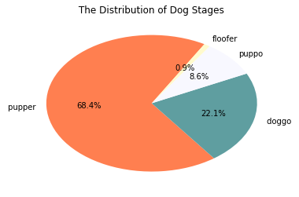

```python
stage= twitter_master.dog_stage.value_counts()
label_list = [" pupper", " doggo ", "puppo", "floofer"]
colors = ['coral', 'cadetblue', 'ghostwhite', 'lemonchiffon']
plt.pie(stage, labels= label_list, autopct='%1.1f%%', startangle=60,colors=colors)
plt.title(' The Distribution of Dog Stages ')
twitter_master.dog_stage.value_counts()
```

From the pie chart, we can see pupper (which is younger and smaller dog, such as chihuahua) is shared the most between other dog stages. it seems people takes more photos of small dogs and share it online.

### The Distribution of Ratings

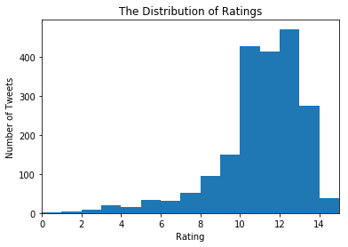

```python
twitter_master['rating_numerator'].plot(kind = 'hist', bins = 15)
plt.xlim(0, 15)
plt.ylabel('Number of Tweets')
plt.xlabel('Rating')
plt.title('The Distribution of Ratings')
plt.show();
```

### Top Dog Predictions

```
golden_retriever      146
Labrador_retriever     94
Pembroke               88
Chihuahua              81
pug                    57
Name: p1, dtype: int64
```

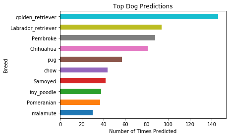

```python
twitter_master['p1'].value_counts()[9::-1].plot(kind='barh')
plt.title('Top Dog Predictions')
plt.xlabel('Number of Times Predicted')
plt.ylabel('Breed')
twitter_master['p1'].value_counts().head(5)
```

Golden retriever is predicated the most. It might be because it shares the most or the algorithm predicts easily more than other dogs.

### • Top Most Favorited Dog

```python
pd.set_option('display.max_columns', None)
```

```python
twitter_master.sort_values(['favorite_count'], ascending =False ).head(3)
```

|  | Unnamed: 0 | tweet_id | timestamp | source | text | expanded_urls | rating_numerator | rating_denominator | name | dog_stage | jpg_url | img_num | p1 | p1_conf | p1_dog | p2 | p2_conf | p2_dog | p3 | p3_conf | p3_dog | favorite_count | retweet_count |
| --- | --- | --- | --- | --- | --- | --- | --- | --- | --- | --- | --- | --- | --- | --- | --- | --- | --- | --- | --- | --- | --- | --- | --- |
| 832 | 838 | 744234799360020481 | 2016-06-18 18:26:18 | <a href="http://twitter.com/download/iphone" r... | Here's a doggo realizing you can stand in a po... | https://twitter.com/dog_rates/status/744234799... | 13 | 10 | NaN | doggo | https://pbs.twimg.com/ext_tw_video_thumb/74423... | 1 | Labrador_retriever | 0.825333 | True | ice_bear | 0.044681 | False | whippet | 0.018442 | True | 156326 | 77860 |
| 320 | 320 | 822872901745569793 | 2017-01-21 18:26:02 | <a href="http://twitter.com/download/iphone" r... | Here's a super supportive puppo participating ... | https://twitter.com/dog_rates/status/822872901... | 13 | 10 | NaN | puppo | https://pbs.twimg.com/media/C2tugXLXgAArJO4.jpg | 1 | Lakeland_terrier | 0.196015 | True | Labrador_retriever | 0.160329 | True | Irish_terrier | 0.069126 | True | 133142 | 43857 |
| 421 | 423 | 807106840509214720 | 2016-12-09 06:17:20 | <a href="http://twitter.com/download/iphone" r... | This is Stephan. He just wants to help. 13/10 ... | https://twitter.com/dog_rates/status/807106840... | 13 | 10 | Stephan | NaN | https://pbs.twimg.com/ext_tw_video_thumb/80710... | 1 | Chihuahua | 0.505370 | True | Pomeranian | 0.120358 | True | toy_terrier | 0.077008 | True | 120802 | 56757 |

```python
twitter_master[twitter_master['tweet_id']==744234799360020481].expanded_urls
```

```
832    https://twitter.com/dog_rates/status/744234799...
Name: expanded_urls, dtype: object
```

Labrador retriever got the most favorited tweet and the most retweet on WeRateDog. The rating is 13/10

### Correlation Between Retweet and Favorite

```python
twitter_master[['retweet_count', 'favorite_count']].corr(method='pearson')
```

|  | retweet_count | favorite_count |
| --- | --- | --- |
| retweet_count | 1.00000 | 0.86093 |
| favorite_count | 0.86093 | 1.00000 |

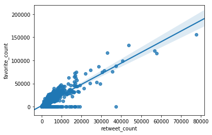

```python
sns.regplot(x="retweet_count", y="favorite_count", data=twitter_master)
```

There is a strong positive relationship between Retweet and Favorite